# EBAIIn2 - ChIP-seq Workshop

### 4.2.3 Customized heatmaps with the EnrichedHeatmap package

So far, we have used functions from *ChIPseeker* and *genomation* to plot the heatmaps. While these functions offer some level of customization, you may need further customization in certain cases. The EnrichedHeatmap package offers an almost complete level of customization to plot heatmaps and heatmap annotations from functional genomic experiments.  
The package is built on the ComplexHeatmap package, which has an extensive documentation and examples.

As an example, let’s plot the enrichment of SOX10 and BRG1 reads around SOX10 peaks.

Step by step:  
- First convert the *ScoreMatrix* objects to *normalizedMatrix* objects that are used by *EnrichedHeatmap*. You can create a normalizedMatrix using the `normalizeToMatrix` function but since we already computed the matrices, we will instead convert them using `as.normalizedMatrix`

**Show code: Convert a ScoreMatrix to a normalizedMatrix**

```r
## Convert signal matrices to normalizedMatrix objects
normat <- list()

## For BRG1 signal:
normat[["BRG1"]] <- as.normalizedMatrix(
  as(smr_at_SOX10peaks[["BRG1"]], "matrix"),
  k_upstream = 150,
  k_downstream = 150,
  k_target = 0,
  extend = c(3000, 3000),
  signal_name = "BRG1",
  target_name = "SOX10 peak centers"
)

## For SOX10 signal:
normat[["SOX10"]] <- as.normalizedMatrix(
  as(smr_at_SOX10peaks[["SOX10"]], "matrix"),
  k_upstream = 150,
  k_downstream = 150,
  k_target = 0,
  extend = c(3000, 3000),
  signal_name = "SOX10",
  target_name = "SOX10 peak centers"
)
```

- Plot BRG1 heatmap using default parameters

**Show code: Plot BRG1 EnrichedHeatmap**

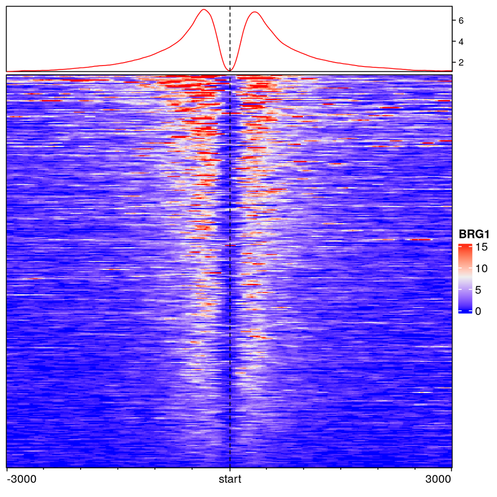

```r
## BRG1 EnrichedHeatmap
EnrichedHeatmap(normat$BRG1, name = "BRG1")
```

- Now use the syntax of *EnrichedHeatmap* to plot both SOX10 and BRG1 heatmaps

**Show code: Plot SOX10 + BRG1 EnrichedHeatmaps**

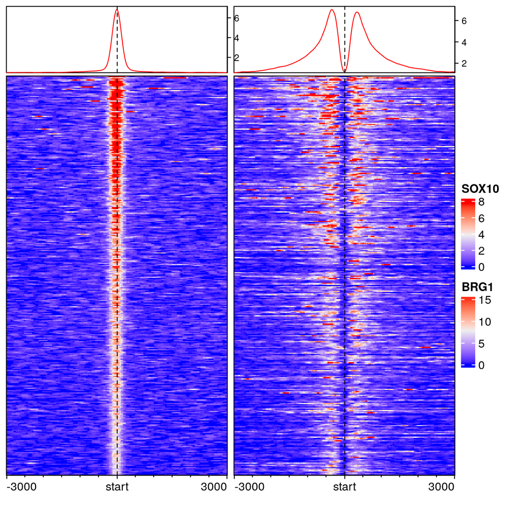

```r
## SOX10 + BRG1 EnrichedHeatmap
EnrichedHeatmap(normat$SOX10, name = "SOX10") +
  EnrichedHeatmap(normat$BRG1, name = "BRG1")
```

- Now let’s cluster the BRG1 signal into 5 groups using kmeans

```r
## make 5 clusters of row using kmeans
set.seed(1234) #for reproducibility
km5 <- kmeans(as.matrix(normat$BRG1),
              centers=5)
# keep the asignment of the rows to clusters
part5clust = km5$cluster
```

- Take a look at the quantiles of the 2 signal matrices to choose the color scales

**Show code: Based on the quantiles of the signal matrices create color scales for the heatmaps. The color scales are created with the `colorRamp2` function from the circlize package which linearly interpolates colors according to break values.**

```r
## Look at the quantiles of the BRG1 matrix
quantile(as(smr_at_SOX10peaks[["BRG1"]], "matrix"), seq(0.95,1,0.01))
```

```
##      95%      96%      97%      98%      99%     100%
##   8.8985   9.7420  10.8640  12.4920  15.5355 105.4010
```

```r
## and for SOX10
quantile(as(smr_at_SOX10peaks[["SOX10"]], "matrix"), seq(0.95,1,0.01))
```

```
##        95%        96%        97%        98%        99%       100%
##   3.436025   4.040000   4.770000   5.814500   7.652500 162.255500
```

```r
## We pick 15 as the max color value (~99th quantile of the matrix) for BRG1
col_brg1 <- colorRamp2(breaks = c(0,10,15),
                       colors = c("white", "blue","black"))
## and 8 for SOX10
col_sox10 <- colorRamp2(breaks = c(0,4,8),
                        colors = c("white", "orange","red"))
```

- Plot the heatmaps of the partitioned SOX10 and BRG1 signals at SOX10 binding sites using EnrichedHeatmap

**Show code: EnrichedHeatmaps of SOX10 and BRG1**

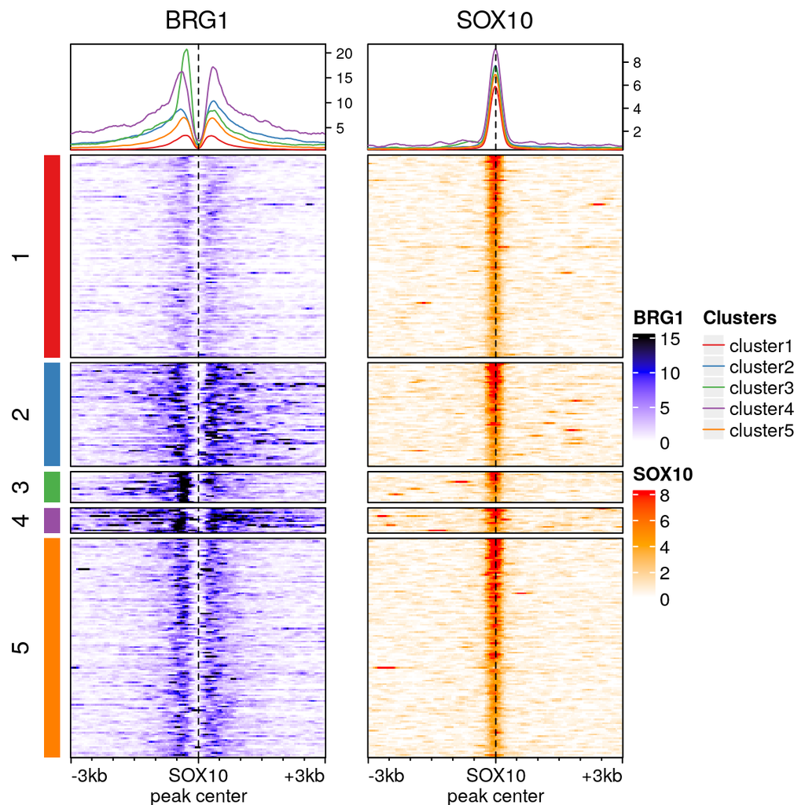

```r
## Create a vector of the colors that will be used for the clusters
clustcolors <- brewer.pal(5,"Set1")
names(clustcolors) <- 1:5

## Create a legend object for the partition
lgd <- Legend(at = paste0("cluster", 1:5),
              title = "Clusters",
              type = "lines", legend_gp = gpar(col = clustcolors))


## In the plot we want:
## 1) the partition in cluster 1 to 8
## 2) the heatmap of BRG1 with the average profiles for the different clusters
## 3) the heatmap of SOX10 with the average profiles for the different clusters
## Define the heatmap list with these 3 objects:
ht_list <- Heatmap(part5clust,
                   col = clustcolors,
                   cluster_rows = FALSE,
                   name = " ",
                   width = unit(3, "mm"),
                   show_heatmap_legend = FALSE) +
  EnrichedHeatmap(normat$BRG1,
                  name = "BRG1",
                  col=col_brg1,
                  top_annotation = HeatmapAnnotation(lines = anno_enriched(gp = gpar(col = clustcolors))),
                  column_title = "BRG1",
                  axis_name = c("-3kb", "SOX10\npeak center", "+3kb")) +
  EnrichedHeatmap(normat$SOX10,
                  name = "SOX10",
                  col=col_sox10,
                  top_annotation = HeatmapAnnotation(lines = anno_enriched(gp = gpar(col = clustcolors))),
                  column_title = "SOX10",
                  axis_name = c("-3kb", "SOX10\npeak center", "+3kb"))

## Draw the heatmap while spliting the rows based on the clusters:
draw(ht_list,
     split = part5clust,
     annotation_legend_list = list(lgd),
     ht_gap = unit(c(2, 8, 8), "mm"))
```

# 5 Analyzing ChIP-seq data together with RNA-seq data

In this paragraph, we will include gene expression data from RNA-seq in our analyses.  
Let’s import the processed data.

```r
# load RNA-seq normalized expression data
RNAseq <- readRDS(file.path(params$workdir,
                            "data", "RNAseq",
                            params$rnaseq)) # RNAseq
head(RNAseq)
```

```
##   Ensembl.Gene.ID    WT.norm shBGR1.norm   logCPM      logFC          FDR
## 1 ENSG00000000003  722.38046   119.10483 4.387012  2.5748948 2.233826e-21
## 2 ENSG00000000419 1481.30280  2514.73393 6.689308 -0.6994493 1.391964e-13
## 3 ENSG00000000457  259.21973   314.27718 5.364018 -0.3167911 3.091766e-05
## 4 ENSG00000000460  333.22470   380.48495 5.562143 -0.1954216 2.875151e-03
## 5 ENSG00000000971   13.42921    13.59959 0.341927  0.6570620 2.536438e-02
## 6 ENSG00000001036 1157.52492  1521.75139 5.567526 -0.3587066 3.117933e-06
##   signif
## 1 stable
## 2 stable
## 3 stable
## 4 stable
## 5 stable
## 6 stable
```

RNA-seq columns:

- Ensembl.Gene.ID: Gene idenfier from ensEMBL (ENSG*****)
- WT.norm: normalized expression for wild type cell lines
- shBGR1.norm: normalized expression for shBRG1 cell lines
- logCPM: average log transformed overall expression
- logFC: log fold-change between the two conditions
- FDR: multiple-testing corrected p-value from edgeR statistical test
- signif (up, down, stable): significance was set as: $FDR < 0.01$, $logCPM > 5$, $abs(logFC) > 1$

Reads from RNA-seq were assigned to genes annotated in ensEMBL and thus are identified with ensEMBL ID. However, in the TxDb package that we loaded, the genes are annotated with ENTREZ IDs. Thus, we need to map the identifiers to each other.

> *NOTE:*: it is generally a good idea to stick to a single annotation file to analyze all your data. But sometimes, you get data from other sources (a colleague, a public database, etc.) so you don’t have the choice.

We use the `OrgDB` object for the human genome to do this. The available information are displayed using `columns()`.

We then use the function `mapIds` from the `AnnotationDbi` package with the keys `ENSEMBL` and `ENTREZID`. You can see that other identifiers are available from this object (e.g: SYMBOL, REFSEQ, UNIPROT etc).

**Show code: map ENSEMBL IDs to ENTREZ IDs**

```r
conv <- mapIds(x = org.Hs.eg.db,
              keys = RNAseq$Ensembl.Gene.ID, # what we want to map
              keytype = "ENSEMBL", # what type of IDs are the keys
              column = "ENTREZID") # which type of ID we want
head(conv)
```

```
## ENSG00000000003 ENSG00000000419 ENSG00000000457 ENSG00000000460 ENSG00000000971
##          "7105"          "8813"         "57147"         "55732"          "3075"
## ENSG00000001036
##          "2519"
```

```r
# names of the vector are ENSEMBL IDs and elements are ENTREZ IDs
```

Let’s take a closer look at the mappings.

**Show code: Explore the conv object**

```r
length(conv) #number of ENSEMBL ids that were mapped (all the rows of RNAseq)
```

```
## [1] 19978
```

```r
sum(is.na(conv)) #number of ENSEMBL ids that could not be mapped to an ENTREZ ID
```

```
## [1] 4218
```

```r
length(conv[!is.na(conv)]) # Number of ENSEMBL ids that were mapped to an ENTREZ ID
```

```
## [1] 15760
```

```r
length(unique(conv[!is.na(conv)])) # Number of unique ENTREZ IDs that corresponded to at least one ENSEMBL ID
```

```
## [1] 15749
```

```r
table(conv[!is.na(conv)])[table(conv[!is.na(conv)]) > 1] # ENTREZ IDs that were mapped to more than one ENSEMBL IDS
```

```
##
## 150763 283440  29994   4102 414245  51326  51463   5554   5664 643836    883
##      2      2      2      2      2      2      2      2      2      2      2
```

The names of the `conv` object should be in the same order as in the column `Ensembl.Gene.ID` of the `RNAsseq` table. We verify it and then assign the `conv` vector as a new `ENTREZID` column in the `RNAseq` dataset

Let’s take a closer look at the mappings.

**Show code: Create an *ENTREZID* column in the *RNASeq* data frame**

```r
identical(names(conv), RNAseq$Ensembl.Gene.ID)
```

```
## [1] TRUE
```

```r
RNAseq$ENTREZID <- conv
```

We will now focus on the TSS of the genes and take a look at the binding of the factors around the TSS.

First, we extract a `GRanges` object with all the TSS.

**Show code: Create a *GRanges* object with the TSS for all genes**

```r
tss <- promoters(genes(txdb), upstream = 0, downstream = 1)
```

```
##   2162 genes were dropped because they have exons located on both strands
##   of the same reference sequence or on more than one reference sequence,
##   so cannot be represented by a single genomic range.
##   Use 'single.strand.genes.only=FALSE' to get all the genes in a
##   GRangesList object, or use suppressMessages() to suppress this message.
```

Then, we filter this `tss` object to keep only the TSS for which we have gene expression data.

```r
tss <- tss[names(tss) %in% RNAseq$ENTREZID[!is.na(RNAseq$ENTREZID)]]
```

Let’s sort the TSS by average gene expression in the cell lines (`logCPM` column). We use the `match` function to find a match between the names of `tss` and the corresponding row in the `RNAseq` dataset

```r
## Add a metadata column with the logCPM from the RNAseq dataset
mcols(tss)$logCPM <- RNAseq$logCPM[match(names(tss), RNAseq$ENTREZID)]
## sort tss by decreasing logCPM
tss <- tss[order(tss$logCPM, decreasing = TRUE)]
```

Import the read coverage for the 3 factors at the TSS

**Show code: Import the read coverage for SOX10, BRG1 and MITF at the TSS**

```r
cvg_tss <- list()
cvg_tss[["SOX10"]] <- readBigWig(file.path(params$workdir, "data", "ChIPseq", params$sox10.bw),
                                 windows = tss + 4000)
cvg_tss[["BRG1"]] <- readBigWig(file.path(params$workdir, "data", "ChIPseq", params$brg1.bw),
                                windows = tss + 4000)
cvg_tss[["MITF"]] <- readBigWig(file.path(params$workdir, "data", "ChIPseq", params$mitf.bw),
                                windows = tss + 4000)
```

Now, we use *genomation* to produce the heatmaps of the different factors in regions covering +/-4kb around the TSS

**Show code: Plot a heatmap of the signal for the 3 factors at the TSS**

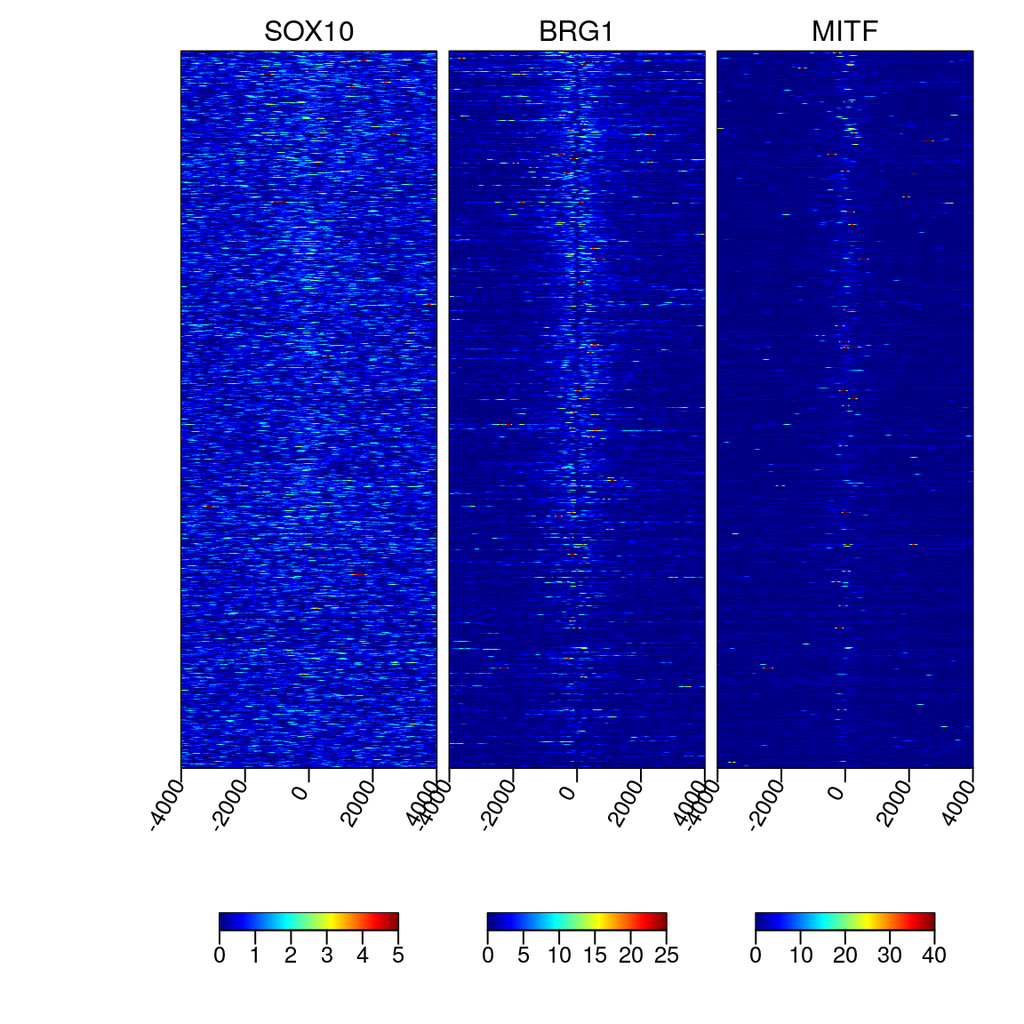

```r
#Get the score matrices around the TSS
smr_at_TSS <- ScoreMatrixList(target = cvg_tss,
                              windows = tss + 4000,
                              bin.num = 400)

#plot the heatmap
multiHeatMatrix(smr_at_TSS,
                xcoords = c(-4000, 4000),
                winsorize = c(0, 99.95))
```

There doesn’t seem to be a very clear association between the binding of the 3 factors and the gene expression level as measured by `logCPM`. Note that `logCPM` is an imperfect measure of the relative gene expression when comparing different genes because it doesn’t take into account the length of the transcripts.  
Anyway, there also seems to be different patterns of BRG1 binding around the TSS. So we are going to use kmeans to cluster the patterns of BRG1 signal into 4 groups.

**Show code: Partition de TSS into 4 groups based on BRG1 signal**

```r
set.seed(123)
km4_tss <- kmeans(as(smr_at_TSS[["BRG1"]], "matrix"),
                  centers = 4)
part_km4_tss <- km4_tss$cluster
```

Take a look at the partition that was made.

**Show code: Plot a heatmap of the signal for the 3 factors for the partitioned TSS**

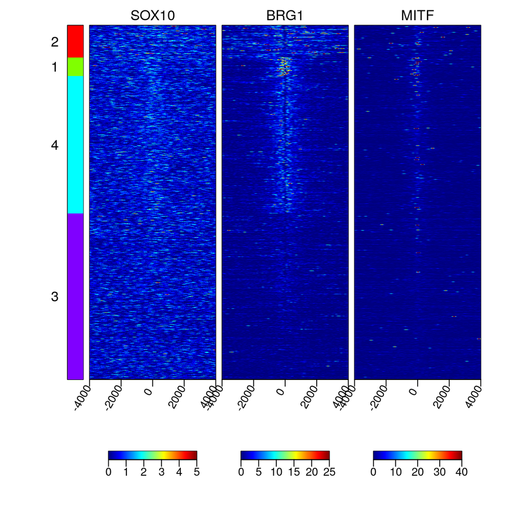

```r
#plot the heatmap
multiHeatMatrix(smr_at_TSS,
                xcoords = c(-4000, 4000),
                winsorize = c(0, 99.95),
                group = factor(part_km4_tss))
```

We would like to know if there is some link between gene expression in WT controls and shBRG1 cells and this partition of the BRG1 binding at the TSS. To do this, we can add the `WT.norm` and `shBRG1` columns to the metadata of the `tss` object. We will also add the `signif` columns that we will need later.

```r
## first get the match between the names of tss and the ENTREZIDs in the RNAseq table
mm <- match(names(tss), RNAseq$ENTREZID)

## then add the columns to the metadata of tss
mcols(tss)$WT.norm <- RNAseq$WT.norm[mm]
mcols(tss)$shBGR1.norm <- RNAseq$shBGR1.norm[mm]
mcols(tss)$signif <- RNAseq$signif[mm]

## also add the info about the clusters
mcols(tss)$clusters <- paste0("cluster", part_km4_tss)
```

Now we can extract a data frame from the `tss` object and reformat it to make a boxplot with ggplot2.

**Show code: Reformat the `mcols` of the *tss* object to prepare it for ggplot2**

```r
exprdf <- tidyr::pivot_longer(as.data.frame(mcols(tss))[, c("WT.norm", "shBGR1.norm", "clusters")],
                              cols = c("WT.norm", "shBGR1.norm"),
                              names_to = "condition",
                              values_to = "expression")
head(exprdf)
```

```
## # A tibble: 6 × 3
##   clusters condition   expression
##   <chr>    <chr>            <dbl>
## 1 cluster2 WT.norm        491811.
## 2 cluster2 shBGR1.norm     61552.
## 3 cluster2 WT.norm        164202.
## 4 cluster2 shBGR1.norm     10699.
## 5 cluster2 WT.norm         64235.
## 6 cluster2 shBGR1.norm     31308.
```

And make the boxplot with ggplot2.

**Show code: Make a boxplot with ggplot2**

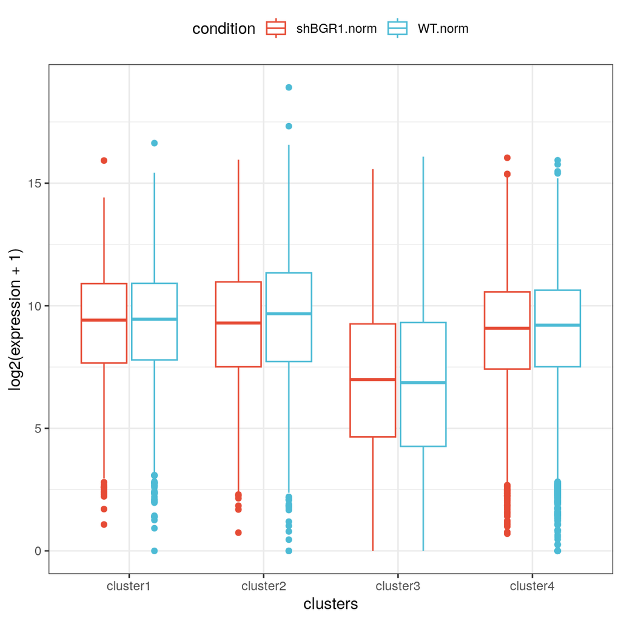

```r
ggplot(exprdf, aes(x = clusters, y = log2(expression+1), color = condition)) +
  geom_boxplot() +
  scale_color_npg() +
  theme_bw() +
  theme(legend.position = "top")
```

Let’s see if the distribution of “significantly” differentially expressed genes differs among clusters.

**Show code: Make a barplot for the `signif` variable for each cluster**

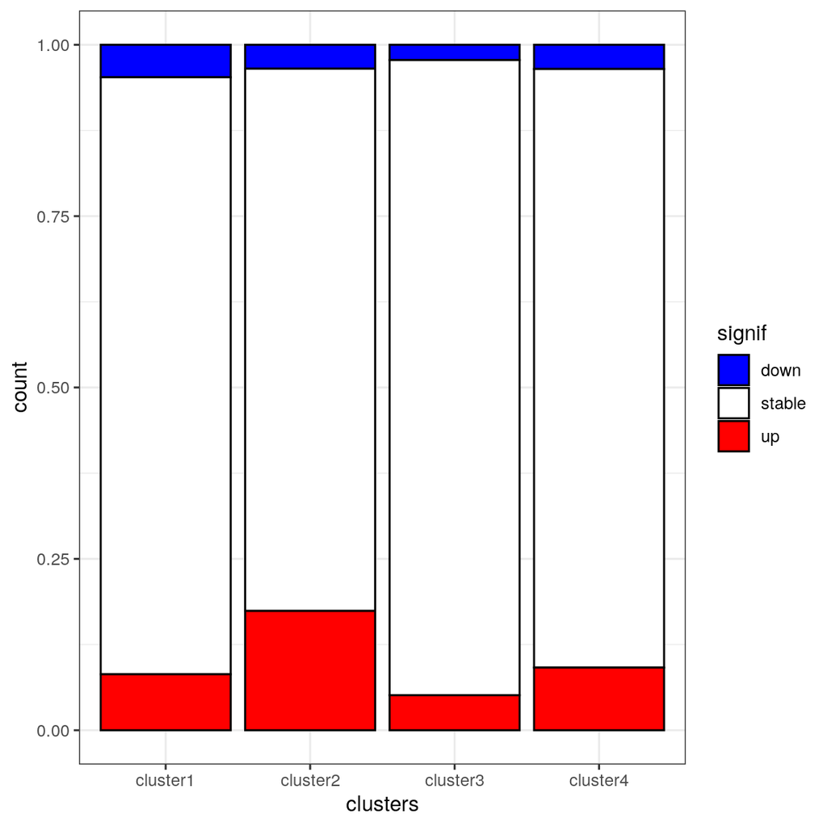

```r
ggplot(as.data.frame(mcols(tss)), aes(x = clusters, fill = signif)) +
  geom_bar(position = "fill", color="black") +
  scale_fill_manual(values=c(up="red",down="blue",stable="white")) +
  theme_bw()
```

We confirm that cluster2 has more significantly upregulated genes than the other clusters.

# 6 Enrichment of functional categories and pathway analyses

## 6.1 GO enrichment analysis of genes in cluster 2

The [clusterprofiler](https://www.bioconductor.org/packages/release/bioc/html/clusterProfiler.html) package provides very useful functions to perform either classical enrichment analysis of functional categories in gene lists or gene set enrichment analyses.  
Here we will use the classical approach, based on the hypergeometric distribution, called “enrichment analysis” or “GO over-representation analysis” in the terminology of *clusterprofiler* documentation.

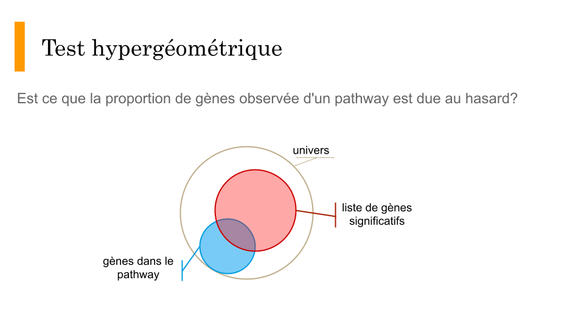

Représentation simplifiée graphique du test hypergéometrique

We can easily extract the IDs of the genes in cluster2 using for example:

- `names(tss)[tss$clusters == "cluster2"]`

The main question that we need to answer is what is the gene universe? In general, you should think as the “gene universe” as the set of genes that could potentially have been selected in your gene list. Since we did different filters, e.g. by selecting genes present in the RNAseq dataset or that had a match between the ENSEMBLID and the ENTREZID, our gene universe does NOT encompass all the genes in the genome. In our case, a good definition of the gene universe would be all the genes in the tss object, since we performed kmeans on these genes to identify genes in cluster 2.

So now, let’s use this info to compute the GO over-representation statistics:

```r
# load the library
library(clusterProfiler)
# Run the enrichment analysis
ego <- enrichGO(gene          = names(tss)[tss$clusters == "cluster2"],
                universe      = names(tss),
                OrgDb         = org.Hs.eg.db,
                ont           = "BP",
                pAdjustMethod = "BH",
                pvalueCutoff  = 0.01,
                qvalueCutoff  = 0.05,
                readable      = TRUE)
```

And take a look at the results:

```r
head(ego)
```

```
##                    ID                                     Description GeneRatio
## GO:0042438 GO:0042438                    melanin biosynthetic process   10/1041
## GO:0046189 GO:0046189 phenol-containing compound biosynthetic process   12/1041
## GO:0006582 GO:0006582                       melanin metabolic process   10/1041
## GO:0044550 GO:0044550       secondary metabolite biosynthetic process   10/1041
## GO:0002385 GO:0002385                         mucosal immune response    8/1041
## GO:0032922 GO:0032922         circadian regulation of gene expression   17/1041
##             BgRatio RichFactor FoldEnrichment   zScore       pvalue    p.adjust
## GO:0042438 21/11891  0.4761905       5.439367 6.306766 3.642124e-06 0.005906749
## GO:0046189 31/11891  0.3870968       4.421679 5.908526 5.578739e-06 0.005906749
## GO:0006582 22/11891  0.4545455       5.192123 6.095926 6.154427e-06 0.005906749
## GO:0044550 22/11891  0.4545455       5.192123 6.095926 6.154427e-06 0.005906749
## GO:0002385 14/11891  0.5714286       6.527240 6.409445 6.247561e-06 0.005906749
## GO:0032922 59/11891  0.2881356       3.291278 5.464823 7.365024e-06 0.005906749
##                 qvalue
## GO:0042438 0.005694326
## GO:0046189 0.005694326
## GO:0006582 0.005694326
## GO:0044550 0.005694326
## GO:0002385 0.005694326
## GO:0032922 0.005694326
##                                                                                                            geneID
## GO:0042438                                                PMEL/TYRP1/DCT/TYR/MFSD12/RAB38/ZEB2/GIPC1/SLC7A11/MC1R
## GO:0046189                                     PMEL/TYRP1/DCT/TYR/MFSD12/RAB38/ZEB2/SNCA/GIPC1/SLC7A11/NR4A2/MC1R
## GO:0006582                                                PMEL/TYRP1/DCT/TYR/MFSD12/RAB38/ZEB2/GIPC1/SLC7A11/MC1R
## GO:0044550                                                PMEL/TYRP1/DCT/TYR/MFSD12/RAB38/ZEB2/GIPC1/SLC7A11/MC1R
## GO:0002385                                                    OTUD7B/RAB17/H2BC21/H2BC8/H2BC12/H2BC11/H2BC4/H2BC7
## GO:0032922 ATF4/PPP1CB/PPP1CC/HDAC2/BHLHE41/CSNK1E/PER1/TOP1/GFPT1/BHLHE40/RAI1/MYCBP2/NPAS2/NCOA2/ID2/NOCT/NR1D1
##            Count
## GO:0042438    10
## GO:0046189    12
## GO:0006582    10
## GO:0044550    10
## GO:0002385     8
## GO:0032922    17
```

## 6.2 KEGG enrichment analysis in DE genes from the different clusters

Now let’s perform the same type of analysis but focusing on the differentially expressed (DE) genes present in each of the 4 clusters. Here, we’re asking if DE genes that have different BRG1 binding patterns at their TSS are enriched in specific KEGG pathways.  
The *clusterProfiler* package provides the function `compareCluster` that allows to analyze and compare enrichment in different group of genes. This function recognizes ENTREZ identifiers.

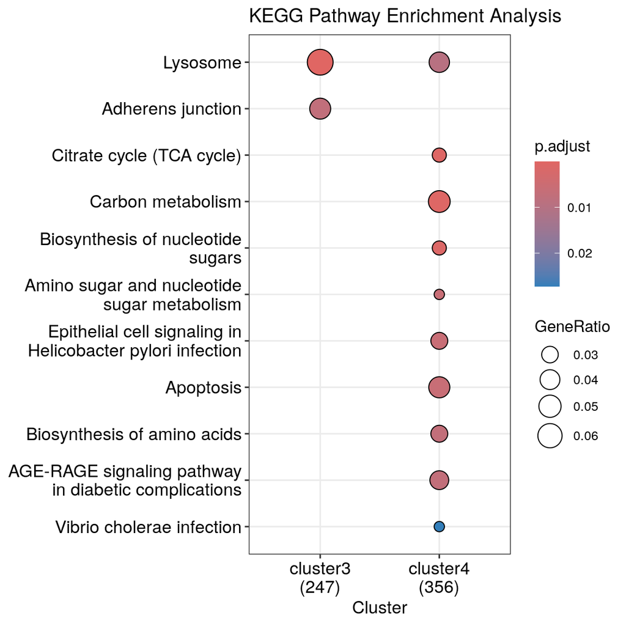

```r
# Select genes whose gene expression is significantly changing
# between conditions
geneList <- tss[tss$signif != "stable",]

# The function split can split a vector to a list following categories
# in an other vector (take a look at the geneList object after running split).
geneList <- split(names(geneList), geneList$clusters)

# Now perform a KEGG pathway over-representation analysis
compKEGG <- compareCluster(geneCluster   = geneList,
                           fun           = "enrichKEGG",
                           pvalueCutoff  = 0.05,
                           pAdjustMethod = "BH")
# Plot the results
dotplot(compKEGG,
        showCategory = 15,
        title = "KEGG Pathway Enrichment Analysis")
```

Let’s focus on cluster 4 and visualize which genes of the the KEGG pathway “Apoptosis” are both differentially expressed and bound by BRG1 and MITF.  
We obtain the identifier of the pathway by looking at the `compKEGG` object:

- `compKEGG@compareClusterResult`

So the ID of the KEGG pathway “Apoptosis” is *hsa04210*.  
We use the `pathview` package which maps differential gene expression values to KEGG pathway maps and create a PNG file in your current directory that you get with `getwd()`.

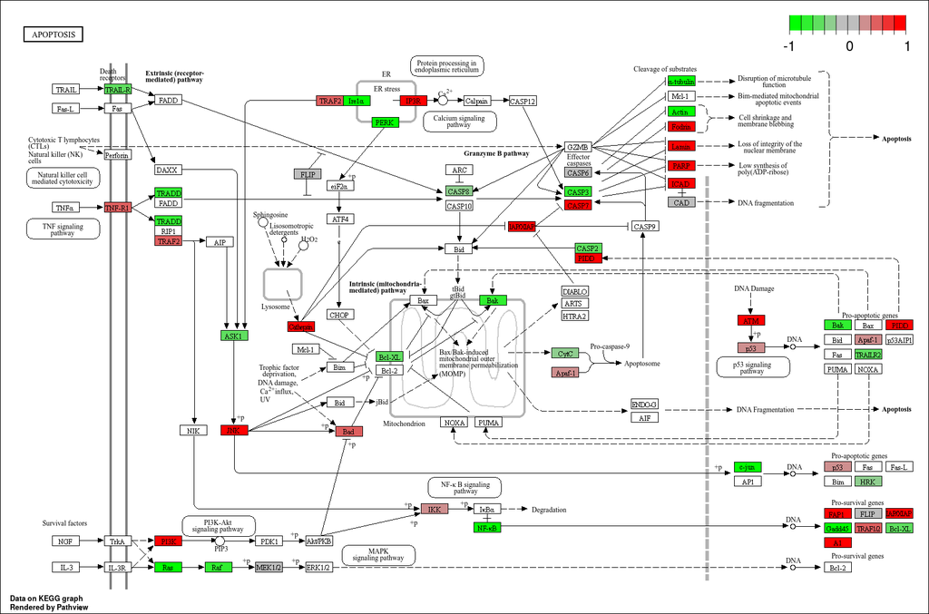

Pathview

```r
# load the library
library(pathview)

# Get the names of the genes in cluster 4
EntrezID.cl4 <- names(tss)[tss$clusters == "cluster4"]

# match these EntrezIDs to the RNAseq dataset
mmid <- match(EntrezID.cl4, RNAseq$ENTREZID)

# Get the log fold-change for these genes from the RNAseq table
logFC.cl4 <- RNAseq$logFC[mmid]
names(logFC.cl4) <- RNAseq$ENTREZID[mmid]

# Create an image of the pathway with colors for differential gene expression
pathview(logFC.cl4, pathway.id = "hsa04210", species = "hsa")
```

# 7 Motif analysis

Often, one of the task associated with ChIP-seq experiments consists in analyzing the sequences that underlie the peaks. The aim could be to identify the binding motif of the factor that was immunoprecipitated, or to evaluate if other factors could bind the same regions.  
Here we will illustrate some basic tasks associated with these aims.

First, load the *Biostrings* library and the *BSgenome* library corresponding to the hg38 human genome.

```r
## Load the Biostrings library and the BSgenome library corresponding to hg38
library(Biostrings)
library(BSgenome.Hsapiens.UCSC.hg38) ## A "Hsapiens" object allows to access the genome sequence
```

## 7.1 De novo motif discovery

Here, we will search for motifs enriched under the SOX10 peaks. Since we do not start from a pre-defined list of motifs, e.g. available in a database like [JASPAR](https://jaspar.elixir.no/) or [CIS-BP](https://cisbp.ccbr.utoronto.ca/), this is called a *de novo* search. We start by sorting SOX10 peaks by qvalue and keep the sequences corresponding to the peak centers +/- 150bp:

```r
sox10peaks_300bp <- resize(peakfilt[["SOX10"]][order(peakfilt[["SOX10"]]$qvalue,
                                                     decreasing = TRUE)],
                           width = 300,
                           fix = "center")
```

Next, we extract the underlying sequences and obtain a `DNAStringSet` object:

```r
sox10_seq <- getSeq(Hsapiens, sox10peaks_300bp)
```

Most of the time, you will want to export these sequences as a fasta file and run an external motif discovery program such as:

- [MEME](https://meme-suite.org/meme/) or
- [RSAT](https://rsat.france-bioinformatique.fr/)

Note that the [TFBStools](https://www.bioconductor.org/packages/release/bioc/html/TFBSTools.html) package has a `runMEME` function that is a wrapper to MEME.  
To export your the sequences you can use:

```r
## Define the path to the fasta file:
myfastafile = file.path("data", "sox10peaks_300bp.fa")
## NOT RUN (already exported): export sequences in fasta format
writeXStringSet(sox10_seq, myfastafile)
```

Here, we will use the [BCRank](https://www.bioconductor.org/packages/release/bioc/html/BCRANK.html) package which can also perform a de novo search for motifs within R. The method takes a list of DNA sequences sorted by some measure of the probability that a relevant motif is present. Here, the qvalue plays the role of this measure, which is why we sorted the peaks by qvalue. `BCrank` takes a long time to run, so we will not run the commands below.

```r
##NOT RUN (too long...)
set.seed(123) #for reproducibility
BCRANKout <- bcrank(myfastafile,
                    restarts = 25,
                    silent = TRUE,
                    use.P1 = TRUE,
                    use.P2 = TRUE)
saveRDS(BCRANKout, file.path("data", "BCRANKout.rds"))
```

Instead, we ran the commands for you and saved the object as an rds file. So we can just import this file and take a look at it:

```r
BCRANKout <- readRDS(file.path("data", "BCRANKout.rds"))
BCRANKout
```

```
##
## An object of class "BCRANKresult"
##
## Top 25 DNA motifs predicted by BCRANK:
##
##       Consensus     Score
## 1       GCWTTGT 122.34709
## 2  VBRVCCTGCTTT  84.48699
## 3   GSRKCANTGTT  75.15736
## 4     VCTGTGAGB  71.66138
## 5   ATKGCACCWDD  69.77417
## 6    GVVTTGRGAB  69.57777
## 7     TYCAMAKCC  65.85154
## 8     TTSCCVAAG  65.51148
## 9   ASWTTTTGCHC  65.39492
```

[output cut: 19 more lines]

We can extract the top motif found by BCRANK with:

```r
topMotif <- toptable(BCRANKout, 1)
```

and extract the Position Weight Matrix (PWM) for this motif and plot the sequence logo with:

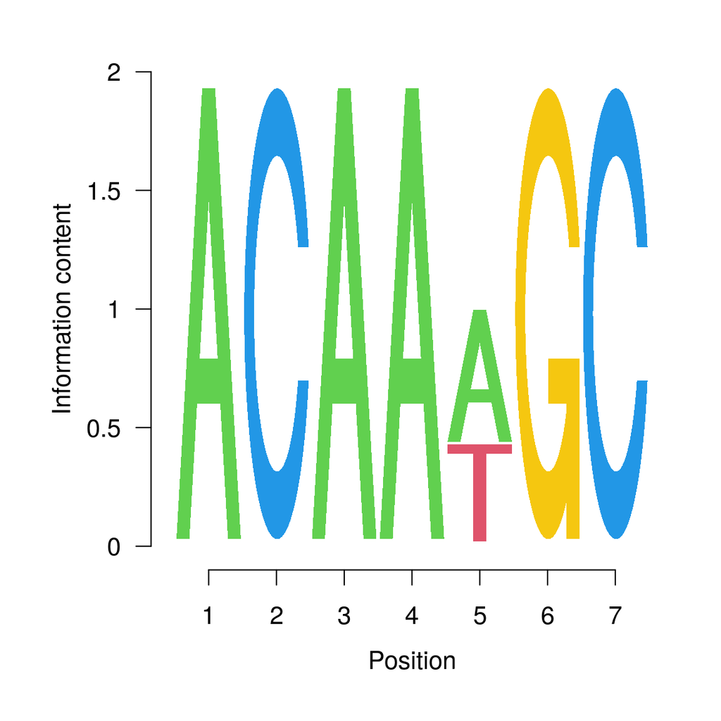

```r
pwmnorm_topmotif <- BCRANK::pwm(topMotif, normalize = TRUE)  #with normalize=TRUE the columns will sum to 1 (PFM)
library(seqLogo)
seqLogo(reverseComplement(pwmnorm_topmotif))
```

You can go to the [JASPAR](https://jaspar.elixir.no/) website and search “SOX10”. You will see that the first motif found by BCRANK is very similar to the motifs that have been found for SOX10. We will actually retrieve and take a look at one of these motifs below.

## 7.2 Searching for known motifs

Another approach consists in searching for known motifs in the ChIP-seq peaks. Since the SOX10 has been extensively studied, there are already SOX10 binding motifs available in the databases.

```r
library(MotifDb)
```

Search for SOX10 motifs in JASPAR databases

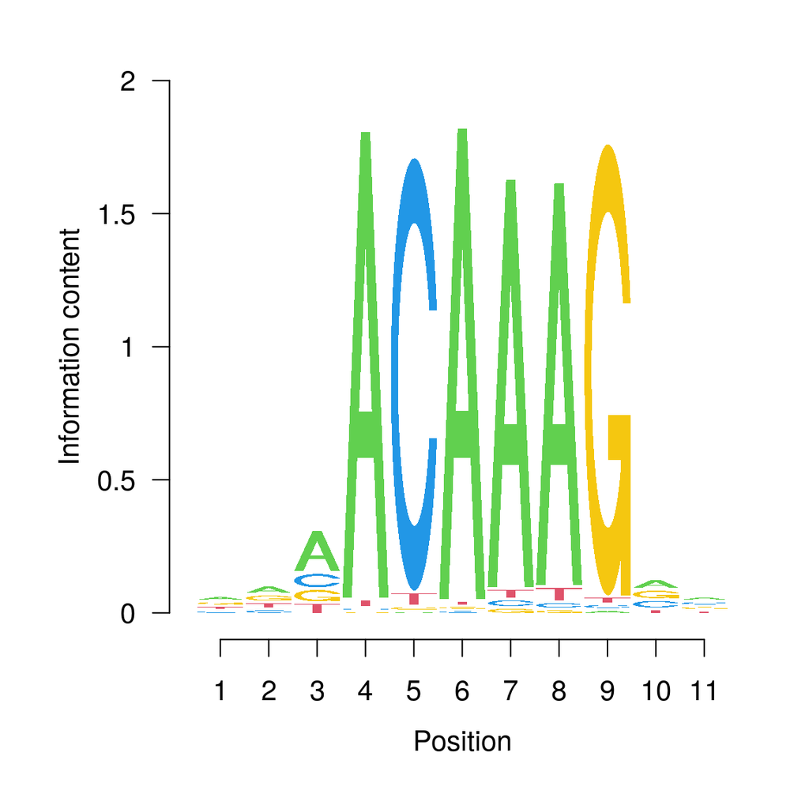

```r
sox10_motifs = MotifDb::query(MotifDb, c("hsapiens", "jaspar", "sox10"))
## We keep the motif from JASPAR 2022
Sox10JASP22 <- sox10_motifs[["Hsapiens-jaspar2022-SOX10-MA0442.2"]]
seqLogo(Sox10JASP22)
```

MotifDb returns a position frequency matrix (PFM) with columns summing to 1. The number of sequences used to build the PFM are available in the elementMetadata or mcols of the object. We use this information to obtain a PWM:

```r
nseq <- as.integer(mcols(sox10_motifs["Hsapiens-jaspar2022-SOX10-MA0442.2"])$sequenceCount)
sox10pfm <- apply(round(nseq * Sox10JASP22,0), 2, as.integer)
rownames(sox10pfm) <- rownames(Sox10JASP22)
Sox10JASP22_PWM <- PWM(sox10pfm)
```

And then use this PWM to screen the whole genome. Again, this takes some time so we saved the rds object for you

```r
## NOT RUN (too long...)
SOX10_hg38 <- matchPWM(Sox10JASP22_PWM,
                       Hsapiens,
                       min.score="90%")
saveRDS(SOX10_hg38, file.path("data", "SOX10_hg38.rds"))
```

We obtain a GRanges with the location of all the motifs:

```r
SOX10_hg38 <- readRDS(file.path("data", "SOX10_hg38.rds"))
SOX10_hg38
```

```
## GRanges object with 3127286 ranges and 2 metadata columns:
##                        seqnames        ranges strand |     score         string
##                           <Rle>     <IRanges>  <Rle> | <numeric> <DNAStringSet>
##         [1]                chr1   11631-11641      + |  0.900030    TCCACAAAGTG
##         [2]                chr1   13572-13582      + |  0.911933    GCTACAAAGGT
##         [3]                chr1   16770-16780      + |  0.935700    AACACAAAGTG
##         [4]                chr1   19982-19992      + |  0.948358    GGGACAAAGGC
##         [5]                chr1   20010-20020      + |  0.930367    CCCACAAAGGA
##         ...                 ...           ...    ... .       ...            ...
##   [3127282] chrX_MU273397v1_alt 314005-314015      - |  0.929517    TGGACAAAGCT
##   [3127283] chrX_MU273397v1_alt 319703-319713      - |  0.952440    AATACAAAGGG
##   [3127284] chrX_MU273397v1_alt 319894-319904      - |  0.909040    AAAACAATGAA
##   [3127285] chrX_MU273397v1_alt 324082-324092      - |  0.955583    CCAACAAAGGC
##   [3127286] chrX_MU273397v1_alt 327059-327069      - |  0.960064    TACACAAAGAA
##   -------
##   seqinfo: 711 sequences (1 circular) from hg38 genome
```

We can now overlap these motifs with our ChIPseq peaks:

```r
## We set a minimum overlap of 11bp (size of the motif) to count only
## the motifs that are fully within the peaks
count_sox10 <- countOverlaps(sox10peaks_300bp,
                             SOX10_hg38,
                             minoverlap = 11)
## Number of peaks that have 0, 1, 2, etc. SOX10 binding sites
table(count_sox10)
```

```
## count_sox10
##    0    1    2    3    4    5
## 1734 1724  611  123   20    2
```

```r
## Percentage of our peaks that have at least one SOX10 binding site:
100*mean(count_sox10>=1)
```

```
## [1] 58.85145
```

```r
set.seed(123) # for reproducibility
count_sox10_tss <- countOverlaps(promoters(genes(txdb), upstream=300, downstream=0)[sample.int(length(sox10peaks_300bp))],
                                 SOX10_hg38,
                                 minoverlap = 11)
```

```
##   2162 genes were dropped because they have exons located on both strands
##   of the same reference sequence or on more than one reference sequence,
##   so cannot be represented by a single genomic range.
##   Use 'single.strand.genes.only=FALSE' to get all the genes in a
##   GRangesList object, or use suppressMessages() to suppress this message.
```

```r
## Percentage of 300bp promoters that contain SOX10 peaks:
100*mean(count_sox10_tss>=1)
```

```
## [1] 10.08543
```

This suggests that the enrichment of SOX10 binding sites in our ChIP-seq peaks is very significant.

# 8 Enriching your analyses with published data

There are multiple ways to access public / published datasets and multiple sources that you can mine in order to compare your own data with what other groups have observed.  
The following databases are only some examples:

-The [(mod)ENCODE](https://www.encodeproject.org/chip-seq-matrix/?type=Experiment&replicates.library.biosample.donor.organism.scientific_name=Homo%20sapiens&assay_title=TF%20ChIP-seq&status=released) project  
- The [UCSC](https://genome-euro.ucsc.edu/cgi-bin/hgGateway?redirect=manual&source=genome.ucsc.edu) genome browser  
- The [GEO](https://www.ncbi.nlm.nih.gov/geo/) database and the [SRA](https://www.ncbi.nlm.nih.gov/sra)  
- The [ENA](https://www.ebi.ac.uk/ena/browser/home) database (which also replicates GEO) and the [ArrayExpress](https://www.ebi.ac.uk/biostudies/arrayexpress) database  
- The [TCGA](https://www.cancer.gov/ccg/research/genome-sequencing/tcga)  
- The [Cistrome](https://cistrome.org/db/) data browser  
- The [ReMap](https://remap.univ-amu.fr/) database  
- The [ChIP atlas](https://chip-atlas.org/)  
- etc…

## 8.1 Mining GEO ChIP-seq data with `ChIPSeeker`

There Gene Expression Omnibus (GEO) contains a vast number of ChIP-seq datasets.  
We can compare our own dataset to those deposited in GEO to search for significant overlap data. Significant overlap of ChIP seq data by different binding proteins may be used to infer cooperative regulation and thus can be used to generate hypotheses.

The [ChIPseeker](https://www.bioconductor.org/packages/release/bioc/html/ChIPseeker.html) package (Wang et al. 2022) package provides useful functions to download and use GEO datasets in R / Bioconductor.

We can collect >100,000 bed files deposited in GEO. You can use `getGEOspecies` to get the number of files available for different species.

```r
getGEOspecies()[1:25,]
```

```
##                                                species Freq
## 1                      Actinobacillus pleuropneumoniae    1
## 2  Actinobacillus pleuropneumoniae serovar 3 str. JL03    1
## 3                                        Aedes aegypti   11
## 4                                             Anabaena    6
## 5                                  Anolis carolinensis    7
## 6                                    Anopheles gambiae    2
## 7                                       Apis mellifera   17
## 8                            Apis mellifera scutellata    1
## 9                                          Arabidopsis   17
## 10                                  Arabidopsis lyrata    4
## 11                                Arabidopsis thaliana 2473
## 12                                Atelerix albiventris    2
## 13                                   Bombus terrestris    8
## 14                                          Bos taurus  257
## 15                             Brachypodium distachyon   10
## 16                           Branchiostoma lanceolatum   93
## 17                                       Brassica rapa   12
## 18                              Caenorhabditis elegans  532
## 19                                  Callithrix jacchus   48
## 20                                    Candida albicans   34
## 21                                Candida dubliniensis   20
## 22                                         Canis lupus    1
## 23                              Canis lupus familiaris   35
## 24                               Capsaspora owczarzaki   21
## 25                                       Carica papaya    1
```

You can also use the `getGEOgenomeVersion` to get the same information but based on genome version used to analyze the data.

You can access the detailed information using the `getGEOInfo` function, for each genome version.

```r
hg38 <- getGEOInfo(genome = "hg38", simplify = TRUE)
head(hg38)
```

```
##       series_id        gsm     organism                                 title
## 16488  GSE58207 GSM1403308 Homo sapiens         Lactimidomycin treated HCT116
## 16489  GSE58207 GSM1403308 Homo sapiens         Lactimidomycin treated HCT116
## 16490  GSE58207 GSM1403307 Homo sapiens          Cycloheximide treated HCT116
## 16491  GSE58207 GSM1403307 Homo sapiens          Cycloheximide treated HCT116
## 20345  GSE67978 GSM1660032 Homo sapiens   H3K27ac_Human_Brain_WhiteMatter_HS2
## 20351  GSE67978 GSM1660029 Homo sapiens H3K27ac_Human_Brain_OccipitalPole_HS2
##                                                                                                                                 supplementary_file
## 16488                                   ftp://ftp.ncbi.nlm.nih.gov/geo/samples/GSM1403nnn/GSM1403308/suppl/GSM1403308_HCT116_LTM_sense.bedGraph.gz
## 16489                              ftp://ftp.ncbi.nlm.nih.gov/geo/samples/GSM1403nnn/GSM1403308/suppl/GSM1403308_HCT116_LTM_anti-sense.bedGraph.gz
## 16490                              ftp://ftp.ncbi.nlm.nih.gov/geo/samples/GSM1403nnn/GSM1403307/suppl/GSM1403307_HCT116_CHX_anti-sense.bedGraph.gz
## 16491                                   ftp://ftp.ncbi.nlm.nih.gov/geo/samples/GSM1403nnn/GSM1403307/suppl/GSM1403307_HCT116_CHX_sense.bedGraph.gz
## 20345   ftp://ftp.ncbi.nlm.nih.gov/geo/samples/GSM1660nnn/GSM1660032/suppl/GSM1660032_H3K27ac_Human_Brain_WhiteMatter_HS2_hg38_peaks.narrowPeak.gz
## 20351 ftp://ftp.ncbi.nlm.nih.gov/geo/samples/GSM1660nnn/GSM1660029/suppl/GSM1660029_H3K27ac_Human_Brain_OccipitalPole_HS2_hg38_peaks.narrowPeak.gz
##       genomeVersion pubmed_id
## 16488          hg38      <NA>
## 16489          hg38      <NA>
## 16490          hg38      <NA>
## 16491          hg38      <NA>
## 20345          hg38      <NA>
## 20351          hg38      <NA>
```

ChIPseeker provides the function `downloadGEObedFiles` to download all the bed files of a particular genome.

```r
downloadGEObedFiles(genome = "hg38", destDir = "hg38")
```

Or a vector of GSM accession number by `downloadGSMbedFiles`.

```r
gsm <- hg38$gsm[sample(nrow(hg38), 10)]
downloadGSMbedFiles(gsm, destDir = "hg38")
```

After the download of bed files from GEO, we can pass them to `enrichPeakOverlap` for testing the significance of the overlaps. Parameter targetPeak can be the folder, e.g. hg38, that containing bed files. `enrichPeakOverlap` will parse the folder and compare all the bed files. It is possible to test the overlap with bed files that are mapped to different genome or different genome versions: `enrichPeakOverlap` provides a parameter `chainFile` that can pass a chain file and liftOver the `targetPeak` to the genome version consistent with `queryPeak.` Significant overlaps can be used to generate hypotheses on cooperative regulation. By mining the data deposited in GEO, we can identify putative complexes or interacting regulators of gene expression or chromatin remodeling for further validation.

## 8.2 The `AnnotationHub`

The *AnnotationHub* is a web resource that provides a central location where genomic files in different formats (e.g. vcf, bed, wig, etc.) and other resources coming from different locations (e.g. UCSC, ENSEMBL, ENCODE, etc.) can be mined and downloaded to enrich your analyses. Importantly, the resource that are available include **metadata** with e.g. description of the experiments, tags and date of modification which are important to figure out where exactly the data comes from and if it fits with the aim of your analyses.  
The [AnnotationHub](https://bioconductor.org/packages/release/bioc/html/AnnotationHub.html) package is a client for R/Bioconductor to search these resources and download the data in appropriate formats for their analysis in the R/Bioconductor environment.  
The client creates and manages a local cache of files that are retrieved by the user, which allows quick and reproducible access to the data.

First we need to create an `AnnotationHub` instance. This will create a local cache on your machine so that repeat queries for the same information (even in different R sessions) will be very fast. By default, the cache will be created in your home folder, which may not be appropriate in a shared server if you have a limited quota of space in your home directory. You can change the location of the cache with:

```r
## NOT RUN: example of how to set the path to the cache
setAnnotationHubOption("CACHE") <- "/shared/projects/projectname/AnnotationHub"
## to check that the path was set correctly:
getAnnotationHubOption("CACHE")
```

Then we create the `AnnotationHub` instance with:

```r
##NOT RUN (too long...)
ah <- AnnotationHub()
# |=============================================================================| 100%
#
# snapshotDate(): 2024-10-28
```

This will take some time the first time you run it since there are a lot of resources available. The `ah` object is quite big but it only contains pointers to online data, not the data itself which would be way too big to download all at once. The information content is changing frequently, which is why there is a `snapshotDate`.

Let’s take a look at the `ah` object:

```r
##NOT RUN
ah
# AnnotationHub with 72100 records
# # snapshotDate(): 2024-10-28
# # $dataprovider: Ensembl, BroadInstitute, UCSC, ftp://ftp.ncbi.nlm.nih.gov/gene/DATA/, FANTOM5,DLRP,IUPHAR,HPRD,STRING,SWISSPROT,TREMBL,ENSEMBL,CELLPHONEDB,...
# # $species: Homo sapiens, Mus musculus, Drosophila melanogaster, Rattus norvegicus, Bos taurus, Pan troglodytes, Danio rerio, Gallus gallus, Sus scrofa, Mon...
# # $rdataclass: GRanges, TwoBitFile, BigWigFile, EnsDb, Rle, OrgDb, SQLiteFile, ChainFile, TxDb, Inparanoid8Db
# # additional mcols(): taxonomyid, genome, description, coordinate_1_based, maintainer, rdatadateadded, preparerclass, tags, rdatapath,
# #   sourceurl, sourcetype
# # retrieve records with, e.g., 'object[["AH5012"]]'
#
#              title
#   AH5012   | Chromosome Band
#   AH5013   | STS Markers
#   AH5014   | FISH Clones
#   AH5015   | Recomb Rate
#   AH5016   | ENCODE Pilot
#   ...        ...
#   AH119506 | Ensembl 113 EnsDb for Zonotrichia albicollis
#   AH119507 | Ensembl 113 EnsDb for Zalophus californianus
#   AH119508 | Ensembl 113 EnsDb for Zosterops lateralis melanops
#   AH119518 | MassBank CompDb for release 2024.06
#   AH119519 | MassBank CompDb for release 2024.11
```

As of `2024-10-28`, the AnnotationHub contains **72,100 records**.  
The `ah` object is organized as a vector (so its `length` is 72100 in my case). You can get information about a single resource by indexing with a single `[`; using two brackets (`[[`) downloads the object:

```r
##NOT RUN
ah[1]
# AnnotationHub with 1 record
# # snapshotDate(): 2024-10-28
# # names(): AH5012
# # $dataprovider: UCSC
# # $species: Homo sapiens
# # $rdataclass: GRanges
# # $rdatadateadded: 2013-03-26
# # $title: Chromosome Band
# # $description: GRanges object from UCSC track 'Chromosome Band'
# # $taxonomyid: 9606
# # $genome: hg19
# # $sourcetype: UCSC track
# # $sourceurl: rtracklayer://hgdownload.cse.ucsc.edu/goldenpath/hg19/database/cytoBand
# # $sourcesize: NA
# # $tags: c("cytoBand", "UCSC", "track", "Gene", "Transcript", "Annotation")
# # retrieve record with 'object[["AH5012"]]'
```

Now, we can use various tools to narrow down the dataset or datasets that are actually of interest for our analyses.  
Let’s say that we are looking for a dataset describing regions in the human genome that are potential distal enhancers. The ENCODE project has typically defined such regions using the data they have produced on e.g. histone marks H3K27ac, H3K4me3 or DNAseI accessibility.

Let’s take a look at the data providers:

```r
##NOT RUN
unique(ah$dataprovider)
#  [1] "UCSC"
#  [2] "Ensembl"
#  [3] "RefNet"
#  [4] "Inparanoid8"
# ...
# [72] "ENCODE"
# ...
# [83] "MGI"
# [84] "ftp://ftp.ncbi.nlm.nih.gov/gene/DATA/"
```

Let’s take a look at the available data from encode:

```r
##NOT RUN
## Number of datasets available from ENCODE (note that there are more since in
## "dataprovider" there is also e.g. "ENCODE Project" or "ENCODE SCREEN v3"
sum(ah$dataprovider == "ENCODE")
# [1] 20
# So there are 20 datasets from the dataprovider "ENCODE"

## Take a look at the titles of these datasets
ah[ah$dataprovider == "ENCODE"]$title
#  [1] "hg38.Kundaje.GRCh38_unified_Excludable"                   "hg38.Bernstein.Mint_Excludable_GRCh38"
#  [3] "hg38.Kundaje.GRCh38.Excludable"                           "hg38.Reddy.wgEncodeDacMapabilityConsensusExcludable.hg38"
#  [5] "hg38.Wold.hg38mitoExcludable"                             "hg38.Yeo.eCLIP_Excludableregions.hg38liftover.bed.fixed"
#  [7] "hg19.Bernstein.Mint_Excludable_hg19"                      "hg19.Birney.wgEncodeDacMapabilityConsensusExcludable"
#  [9] "hg19.Crawford.wgEncodeDukeMapabilityRegionsExcludable"    "hg19.Wold.hg19mitoExcludable"
# [11] "hg19.Yeo.eCLIP_Excludableregions.hg19"                    "mm10.Hardison.Excludable.full"
# [13] "mm10.Hardison.psuExcludable.mm10"                         "mm10.Kundaje.anshul.Excludable.mm10"
# [15] "mm10.Kundaje.mm10.Excludable"                             "mm10.Wold.mm10mitoExcludable"
# [17] "mm9.Wold.mm9mitoExcludable"                               "ENCODE_dELS_regions"
# [19] "ENCODE_pELS_regions"                                      "ENCODE_PLS_regions"
```

I wonder what *“PLS_regions”* are 🤔 and I want to know more. So let’s take a look at the object description:

```r
##NOT RUN
ah[ah$dataprovider == "ENCODE" & ah$title == "ENCODE_PLS_regions"]$description
# [1] "A GRanges object containing regions of candidate cis-regulatory elements with promoter-like signatures
# as identified by the ENCODE SCREEN project. These consist of regions with high H3K4me3 and DNase signal, and
# located within 200 bp of a GENCODEtranscription start site."
```

OK, this looks very close to what we are looking for and I suppose that *pELS* and *dELS* refer to *proximal* and *distal* enhancer-like signatures. Let’s verify:

```r
##NOT RUN
ah[ah$dataprovider == "ENCODE" & ah$title == "ENCODE_dELS_regions"]$description
# [1] "A GRanges object containing regions of candidate cis-regulatory elements with distal enhancer-like
# signatures as identified by the ENCODE SCREEN project. These consist of regions with high H3K27ac and
# DNase signal, but low H3K4me3 signal, and located more than 2kb from GENCODE transcription start sites."
```

So now we can get the names of the object, download it and use it in R (it’s a *GRanges* object):

```r
##NOT RUN
## Get the name / ID of the dataset
names(ah[ah$dataprovider == "ENCODE" & ah$title == "ENCODE_dELS_regions"])
# [1] "AH116727"

## Download the dataset (use double brackets `[[`)
dELS <- ah[["AH116727"]]
# downloading 1 resources
# retrieving 1 resource
#   |===========================================================================| 100%
#
# loading from cache
# require(“GenomicRanges”)

## Take a look at the object:
dELS
# GRanges object with 786756 ranges and 0 metadata columns:
#            seqnames            ranges strand
#               <Rle>         <IRanges>  <Rle>
#        [1]     chr1     271227-271468      *
#        [2]     chr1     274330-274481      *
#        [3]     chr1     605331-605668      *
#        [4]     chr1     727122-727350      *
#        [5]     chr1     807737-807916      *
#        ...      ...               ...    ...
#   [786752]     chrY 26319537-26319816      *
#   [786753]     chrY 26319848-26320155      *
#   [786754]     chrY 26363541-26363721      *
#   [786755]     chrY 26670949-26671287      *
#   [786756]     chrY 26671293-26671478      *
#   -------
#   seqinfo: 24 sequences from an unspecified genome; no seqlengths

## Since seqinfo has not been set, you may wonder which genome version was used.
## You can get this info from the metadata of the ah object:
ah['AH116727']$genome
# [1] "hg38"
```

In another example, we will use some useful function to search the AnnotationHub:

- `subset` (or `[`) to do a specific subseting operation.
- `query` to do a command-line search over the metadata of the hub.
- `display` to get a Shiny interface in a browser, so you can browse the object.

We would like to know if there are any other dataset available for MITF in human. We first filter the hub to keep only the datasets obtained in human, or the datasets where the *species* is unspecified (`NA`), in case some metadata is missing.

```r
##NOT RUN
ah <- subset(ah, species %in% c(NA, "Homo sapiens"))
```

Then we query the metadata for MITF:

```r
##NOT RUN
query(ah, "MITF")
# AnnotationHub with 1 record
# # snapshotDate(): 2024-10-28
# # names(): AH22280
# # $dataprovider: Pazar
# # $species: NA
# # $rdataclass: GRanges
# # $rdatadateadded: 2015-03-09
# # $title: pazar_MITF_Strub_20120522.csv
# # $description: TF - Target Gene file from pazar_MITF_Strub_20120522
# # $taxonomyid: NA
# # $genome: NA
# # $sourcetype: CSV
# # $sourceurl: http://www.pazar.info/tftargets/pazar_MITF_Strub_20120522.csv
# # $sourcesize: 34964
# # $tags: c("Pazar", "Transcription Factors")
# # retrieve record with 'object[["AH22280"]]'
```

Indeed this dataset does not contain all the metadata but there is a link to the original source file and searching the web for “MITF, Strub” quickly gets you to [this publication](https://pubmed.ncbi.nlm.nih.gov/21258399/) where all the info is available to evaluate if this dataset is relevant for us.

Finally, another way to mine the AnnotationHub is to use a browser with:

```r
##NOT RUN
outdata <- display(ah)
```

Note how we assign the call to the `display` function to an R object (`oudata`) so that we can actually capture the selection of datasets that we will make from the browser into our R session.

# 9 Importance of the annotation databases

In previous annotation steps, we have annotated peaks using annotation from UCSC’s knownGene. The database chosen for annotation can have an impact on subsequent results including data integration such as comparison between genes associated to peaks and gene expression using RNA-seq data for instance.

Let’s look at the overlap between genes expressed in RNA-seq data with genes associated to peaks (let’s remind that peaks are associated to closest genes if no other evidences are used).

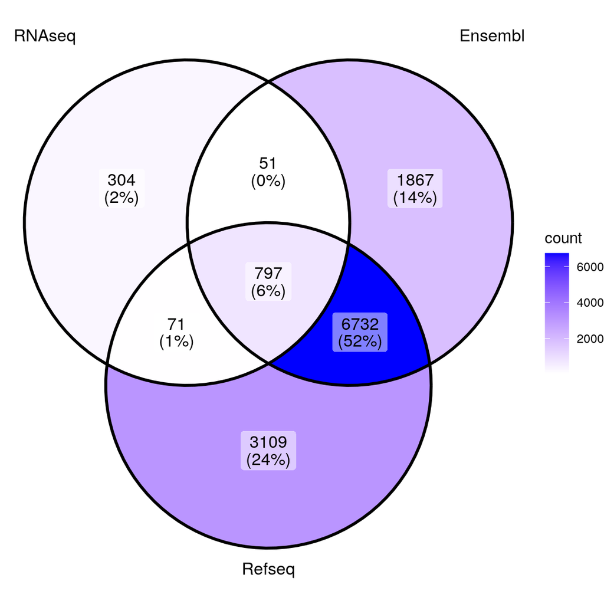

```r
## Download GTF files
library(GenomicFeatures)

## Import BRG1 peaks annotated with Ensembl and Refseq annotation
annot <- readRDS(file.path(params$workdir, "data", params$annot))

## Here is how annotation data were downloaded
# txdb.ensembl = makeTxDbFromGFF("data/ChIPseq/Homo_sapiens.GRCh38.103_UCSC_chr.gtf.gz")
# txdb.refseq = makeTxDbFromUCSC(genome="hg38", tablename="refGene")

## Here is how annotation was performed
# annot <- list()
# annot[["ensembl"]] <- annotatePeak(peaks$BRG1, tssRegion=c(-1000, 100), TxDb=txdb.ensembl, annoDb="org.Hs.eg.db")
# annot[["refseq"]] <- annotatePeak(peaks$BRG1, tssRegion=c(-1000, 100), TxDb=txdb.refseq, annoDb="org.Hs.eg.db")

## Add Gene symbols to RNAseq data
conv.symbol <- mapIds(x = org.Hs.eg.db,
                      keys = RNAseq$Ensembl.Gene.ID, # what do we want to be mapped
                      column = c("SYMBOL"), # which type of ID we want
                      keytype = "ENSEMBL") # what type of ID we give

mEnsRS <- match(RNAseq$Ensembl.Gene.ID,
           names(conv.symbol))

RNAseq$SYMBOL <- conv.symbol[mEnsRS]

## Now let's create a venn diagram that compares peak annotation with
## refseq or Ensembl
library(ggVennDiagram)
x <- list(RNAseq = RNAseq[RNAseq$signif=="up",]$SYMBOL,
          Ensembl = as.data.frame(annot$ensembl)$SYMBOL,
          Refseq = as.data.frame(annot$refseq)$SYMBOL
)

ggVennDiagram(x) + scale_fill_gradient(low="white",high = "blue")
```

# References

“(2014) Mod/Mouse/humanENCODE: Blacklisted Genomic Regions for Functional Genomics Analysis - Anshul Kundaje.” n.d. Accessed August 26, 2016. https://sites.google.com/site/anshulkundaje/projects/blacklists.

Anders, Simon, Paul Theodor Pyl, and Wolfgang Huber. 2015. “HTSeq—a Python Framework to Work with High-Throughput Sequencing Data.” *Bioinformatics* 31 (2): 166–69. https://doi.org/10.1093/bioinformatics/btu638.

Anders, and Huber. 2010. “Differential Expression Analysis for Sequence Count Data.” *Genome Biology* 11.

Dobin, Alexander, Carrie A. Davis, Felix Schlesinger, Jorg Drenkow, Chris Zaleski, Sonali Jha, Philippe Batut, Mark Chaisson, and Thomas R. Gingeras. 2013. “STAR: Ultrafast Universal RNA-Seq Aligner.” *Bioinformatics* 29 (1): 15–21. https://doi.org/10.1093/bioinformatics/bts635.

Heinz, Sven, Christopher Benner, Nathanael Spann, Eric Bertolino, Yin C. Lin, Peter Laslo, Jason X. Cheng, Cornelis Murre, Harinder Singh, and Christopher K. Glass. 2010. “Simple Combinations of Lineage-Determining Transcription Factors Prime Cis-Regulatory Elements Required for Macrophage and b Cell Identities.” *Molecular Cell* 38 (4): 576–89. https://doi.org/10.1016/j.molcel.2010.05.004.

Langmead, Ben, Cole Trapnell, Mihai Pop, and Steven L. Salzberg. 2009. “Ultrafast and Memory-Efficient Alignment of Short DNA Sequences to the Human Genome.” *Genome Biology* 10 (3): R25. https://doi.org/10.1186/gb-2009-10-3-r25.

Laurette, Patrick, Thomas Strub, Dana Koludrovic, Céline Keime, Stéphanie Le Gras, Hannah Seberg, Eric Van Otterloo, et al. 2015. “Transcription Factor MITF and Remodeller BRG1 Define Chromatin Organisation at Regulatory Elements in Melanoma Cells.” Edited by Michael R Green. *eLife* 4 (March): e06857. https://doi.org/10.7554/eLife.06857.

Martin, Marcel. 2011. “Cutadapt Removes Adapter Sequences from High-Throughput Sequencing Reads.” *EMBnet.journal* 17 (1): pp. 10–12. http://journal.embnet.org/index.php/embnetjournal/article/view/200.

Quinlan, Aaron R., and Ira M. Hall. 2010. “BEDTools: A Flexible Suite of Utilities for Comparing Genomic Features.” *Bioinformatics* 26 (6): 841–42. https://doi.org/10.1093/bioinformatics/btq033.

Robinson, Mark D, Davis J McCarthy, and Gordon K Smyth. 2010. “edgeR: A Bioconductor Package for Differential Expression Analysis of Digital Gene Expression Data.” *Bioinformatics* 26 (1): 139–40. https://doi.org/10.1093/bioinformatics/btp616.

Wang, Qianwen, Ming Li, Tianzhi Wu, Li Zhan, Lin Li, Meijun Chen, Wenqin Xie, et al. 2022. “Exploring Epigenomic Datasets by ChIPseeker.” *Curr. Protoc.* 2 (10): e585.